# DEPENDENCIA ECONÓMICA

Edgardo Flores Gutiérrez

2025-09-28

# Introducción

El siguiente análisis se sustenta en la ENIGH 2024 publicada por el INEGI, centrándose en las tablas de datos “poblacion”, “ingresos” y “viviendas”, que nos permite conocer las características sociodemográficas y ocupacionales de los integrantes del hogar, ademas de la variable tam_loc que indica el tamaño de localidad, que se encuentra en la tabla viviendas y la variable ing_tri que nos permite descifrar si los individuos evaluados son dependientes económicos.

La encuesta contiene un diseño muestral estatrificado, con representatividad nacional y subnacional, por lo que, la encuesta cuenta con tres variables para la realización del diseño muestral y realizar inferencia estadística:

1. factor: peso de expansión
2. est_dis: estrato
3. upm: unidad primaria de muestreo.

El análisis tiene como objetivo conocer el número de individuos que son dependientes económicos con un enfoque de género.

Estructura del análisis:

- Definición del diseño muestral
- Análisis estadístico por segmento:
  - Medidas de tendencia central
  - Comparación de medias y medianas entre grupos
- Visualización de resultados (Data visualization)
- Modelo de regresión final con ajuste por diseño muestral (opcional)

# Diseño muestral

El diseño muestral con el que fue recolectada la ENIGH 2024 valida los resultados del análisis estadístico,

De acuerdo con el documento metodológico de la ENIGH 2024 Nueva Serie Descripción de la base de datos (INEGI, Capítulo 4) est_dis corresponde a un código de estrato estadístico definido por características como: • Nivel de urbanización (urbano/rural) • Tamaño de localidad • Categoría de la entidad federativa (grande, mediana, pequeña) • Dominio de estudio (entidad, ciudad, región)

UPM identifica cada Unidad Primaria de Muestreo, que en zonas urbanas equivale generalmente a una manzana o conjunto de manzanas, y en zonas rurales, a localidades. Las UPM se seleccionan con probabilidad proporcional al tamaño poblacional, y constituyen la base para la selección de viviendas.

Factor: el factor de expansión constituye el peso que se le da a cada unidad muestral para generalizar los resultados de la muestra a la población.

El **diseño muestral** es el plan o estrategia que se utiliza para seleccionar una muestra a partir de una población más grande. En esencia, es el conjunto de procedimientos que nos permite elegir un subgrupo representativo (la muestra) de un grupo total (la población) con el fin de estudiarlo y poder generalizar los resultados a toda la población.

El objetivo principal es obtener información precisa y confiable sobre la población sin tener que estudiar a cada uno de sus individuos, lo que a menudo sería demasiado costoso, lento o simplemente imposible.

**Definición del diseño muestral**

# Análisis estadístico

Para realizar un análisis estádistico correcto, es preciso conocer la cantidad de personas que representa el diseño muestral, así como las medidas de tendencia central.

Población total que son dependientes económicos (por sexo)

## **Dependientes económicos (por sexo)**

|  | Total | Error_Estandar |
| --- | --- | --- |
| sexoHombre | 9,847,101 | 117,448 |
| sexoMujer | 22,036,511 | 180,917 |

## **Total de dependientes económicos**

```
## El número total de personas (población expandida) que son dependientes económicos es: 31,883,612
```

## **Dependientes económicos por tipo de dependencia y sexo**

- Variable 1: tipo_dependencia, clasifica a los dependientes en dos grupos basados en ‘ingreso_mensual’
- Variable 2: Sexo como Factor (Categórico)
- Variable 3: Agregamos una columna ‘uno’ que vale 1 para cada individuo (fines técnicos)

## **Tipo de dependientes económicos (total por sexo)**

Calculamos el total de dependientes económicos por no ser perceptores de ingresos y por percibir ingresos por transferencias, desagregado por sexo y con porcentajes del total.

```
##                                          tipo_dependencia   sexo      Total
## 1                1. Dependientes por no percibir ingresos Hombre  7,614,253
## 2 2. Dependientes por percibir ingresos de transferencias Hombre  2,232,848
## 3                1. Dependientes por no percibir ingresos  Mujer 17,640,370
## 4 2. Dependientes por percibir ingresos de transferencias  Mujer  4,396,141
##   Porcentaje_general Error_Estandar
## 1              23.9%        105,415
## 2               7.0%         49,889
## 3              55.3%        164,797
## 4              13.8%         70,106
```

## Composición interna

Calculamos la proporción de hombres y mujeres que son dependientes económicos por no ser perceptores de ingresos y por ser perceptores de ingresos de transferencias

```
##                                          tipo_dependencia Porc_Hombre_fmt
## 1                1. Dependientes por no percibir ingresos           30.1%
## 2 2. Dependientes por percibir ingresos de transferencias           33.7%
##   Porc_Mujer_fmt
## 1          69.9%
## 2          66.3%
```

## Estadísticas descriptivas

### Edad

- Edad promedio y mediana de la población que son dependientes económicos (por sexo)

```
##     sexo                                        tipo_dependencia media
## 1 Hombre                1. Dependientes por no percibir ingresos    22
## 2 Hombre 2. Dependientes por percibir ingresos de transferencias    42
## 3  Mujer                1. Dependientes por no percibir ingresos    32
## 4  Mujer 2. Dependientes por percibir ingresos de transferencias    43
##    se_media mediana se_mediana
## 1 0.1540095      17  0.2550639
## 2 0.5694979      17  0.2550639
## 3 0.1241577      31  0.2550725
## 4 0.3356181      31  0.2550725
```

**Gráfica del Promedio de edad de la población con Dependencia Económica**

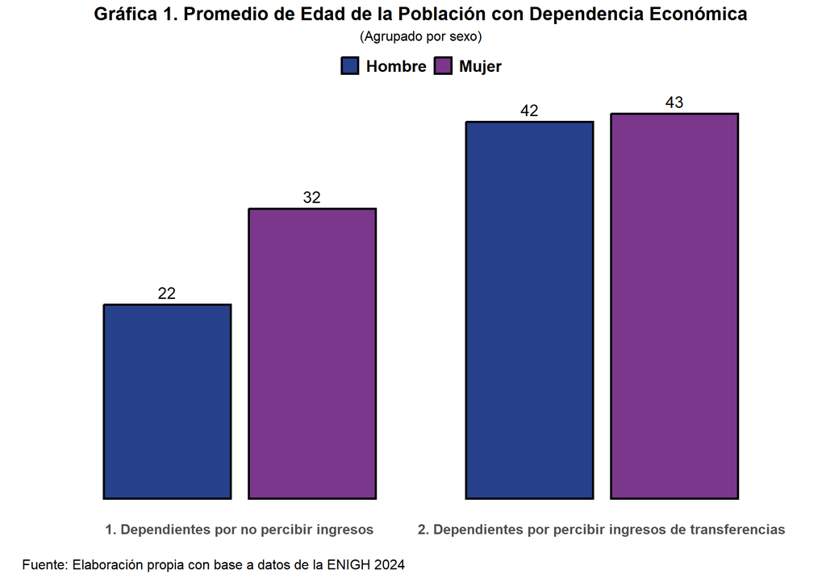

**Gráfico de Boxplot para visualizar la dispersión de la edad**

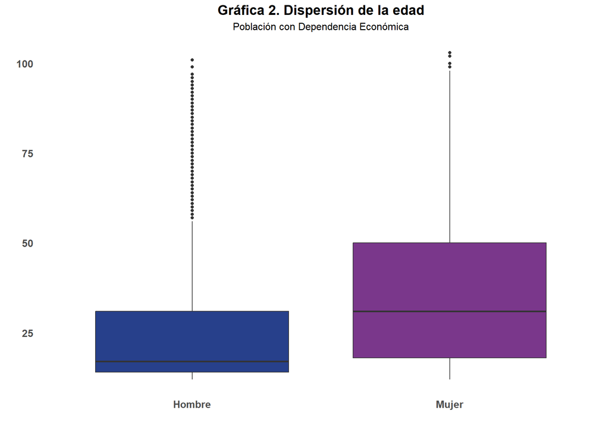

### Horas de trabajo no remunerado

- Horas semanales promedio y mediana de trabajo no remunerado (por sexo) de la población con dependencia económica

```
##     sexo                                        tipo_dependencia    media
## 1 Hombre                1. Dependientes por no percibir ingresos 10.30696
## 2 Hombre 2. Dependientes por percibir ingresos de transferencias 14.26976
## 3  Mujer                1. Dependientes por no percibir ingresos 31.08658
## 4  Mujer 2. Dependientes por percibir ingresos de transferencias 31.45158
##    se_media mediana se_mediana media_hm mediana_hm
## 1 0.1599390       7  0.2550639 10:18:25   07:00:00
## 2 0.3769689       7  0.2550639 14:16:11   07:00:00
## 3 0.2219700      25  0.5101450 31:05:12   25:00:00
## 4 0.4063543      25  0.5101450 31:27:06   25:00:00
```

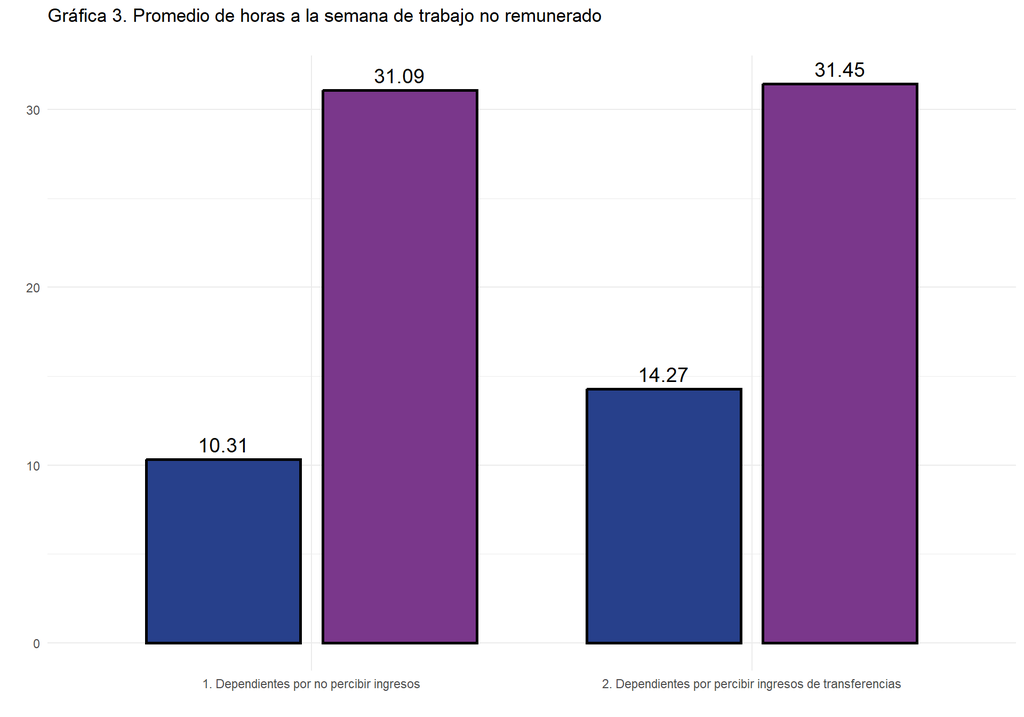

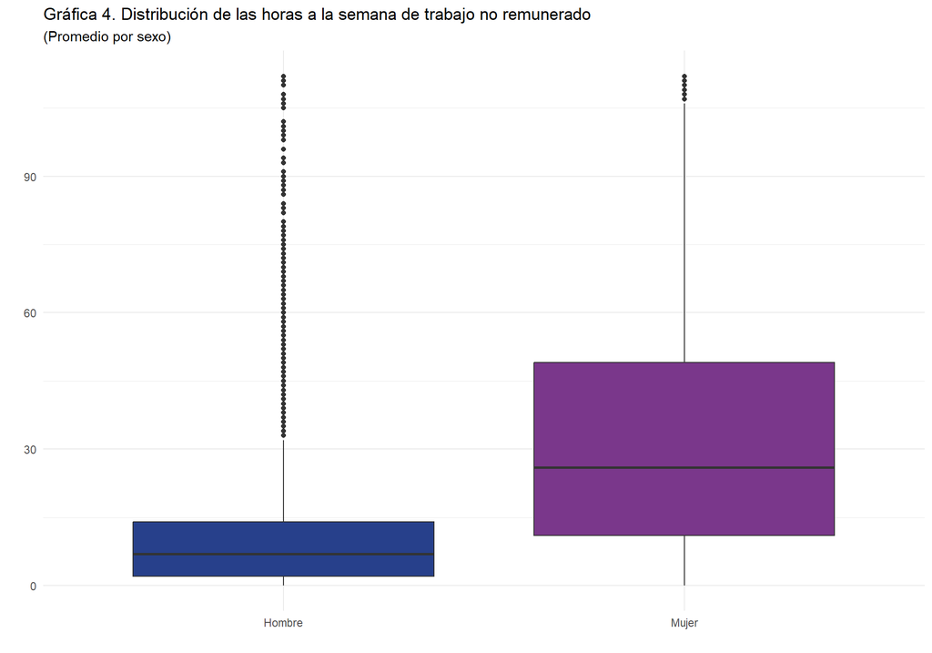

Dada la fuerte asimetria y la gran cantidad de valores atípicos (outliers) en las horas de trabajo no remunerado (Gráfica 4), la **mediana** es una medida de tendencia central mucho más adecuada y robusta que la **media**.

#### Transformación Logarítimica

Con la intención de normalizar los datos, se realiza una transformación logarítmica. El objetivo es crear una nueva columna que contenga el logaritmo de las horas de trabajo no remunerado.

#### Justificación de la Transformación Logarítmica

La decisión de transformar una variable $Y$ a $log(Y)$ no es una medida arbitraria para alterar la escala de los datos, sino un procedimiento estándar en econometría y estadística que se justifica por una o más de las siguientes razones teóricas y prácticas:

- **Mecanismo de Acción:** La función logarítmica es cóncava, lo que significa que “comprime” la escala de los valores altos en mayor medida que la de los valores bajos. Esto reduce el impacto de los valores extremos en la cola derecha de la distribución, resultando en una distribución transformada mucho más simétrica y, a menudo, aproximadamente normal.
- **Beneficio Estadístico:** Al normalizar la distribución de la variable (o, más precisamente, la de los residuos del modelo), se obtienen estimadores más eficientes y se valida el uso de pruebas de significancia (valores p) y la construcción de intervalos de confianza, los cuales dependen del supuesto de normalidad.

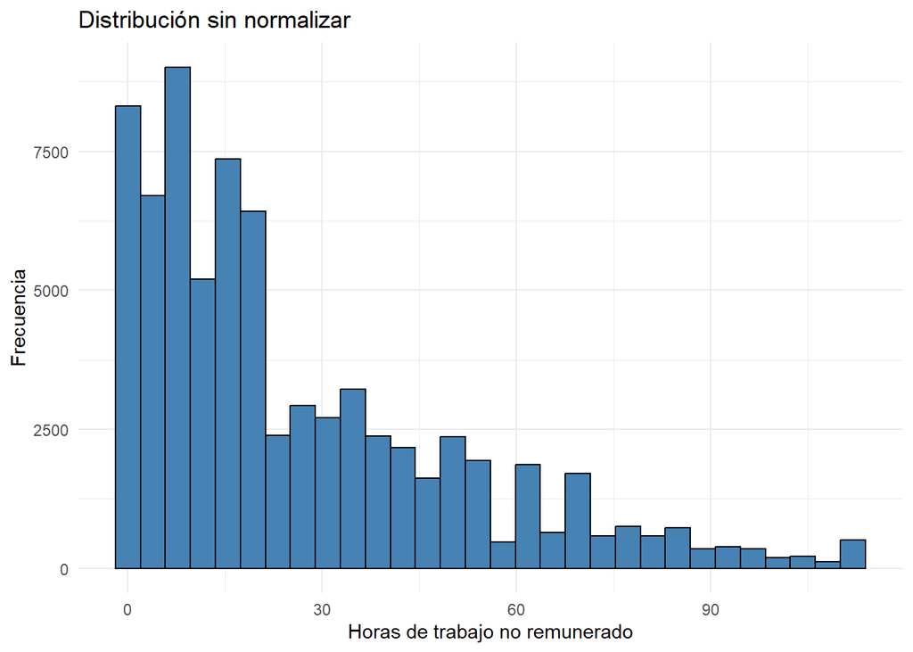

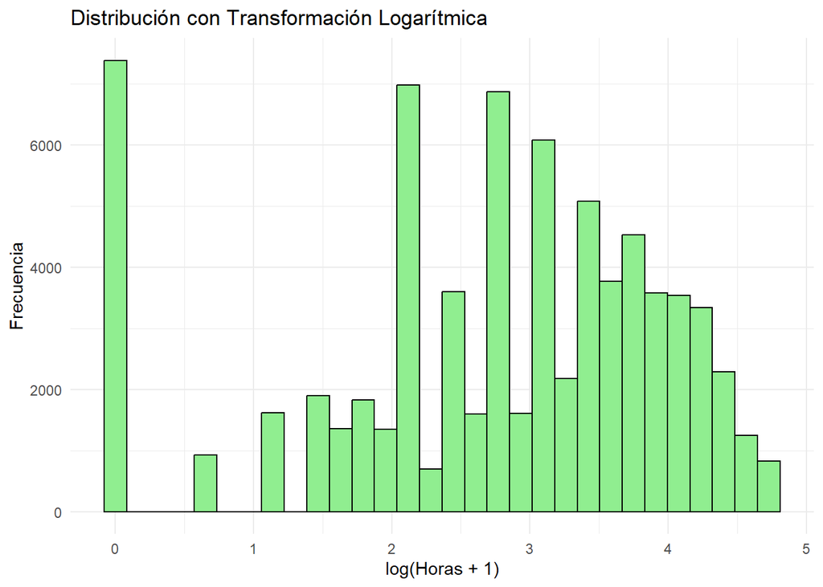

```
## [1] "Media Aritmética Original (sesgada): 25.92"
```

```
## [1] "Mediana Original (robusta): 18"
```

```
## [1] "Media Geométrica (robusta e interpretable): 14.14"
```

### Ingreso mensual

- Ingreso mensual promedio y mediana de la población con dependencia económica (por sexo).

**Cálculos estadísticos con el diseño muestral**

**Tabla para visualizar los cálculos estadísticos**

```
##     sexo                                        tipo_dependencia media se_media
## 1 Hombre                1. Dependientes por no percibir ingresos     0   0.0000
## 2 Hombre 2. Dependientes por percibir ingresos de transferencias  8084 247.1054
## 3  Mujer                1. Dependientes por no percibir ingresos     0   0.0000
## 4  Mujer 2. Dependientes por percibir ingresos de transferencias  5450 119.7200
##   mediana se_mediana
## 1       0   41.83048
## 2       0   41.83048
## 3       0   37.75073
## 4       0   37.75073
```

**Gráfica del Promedio del Ingreso mensual de la población con Dependencia Económica**

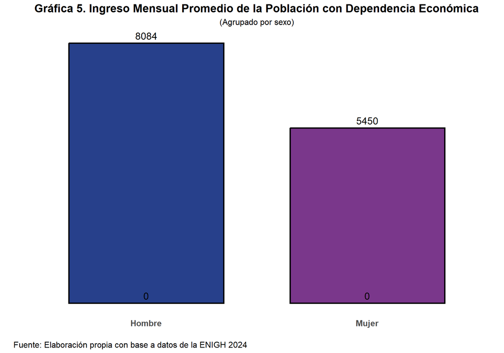

**Gráfico de Boxplot para visualizar la dispersión del ingreso mensual**

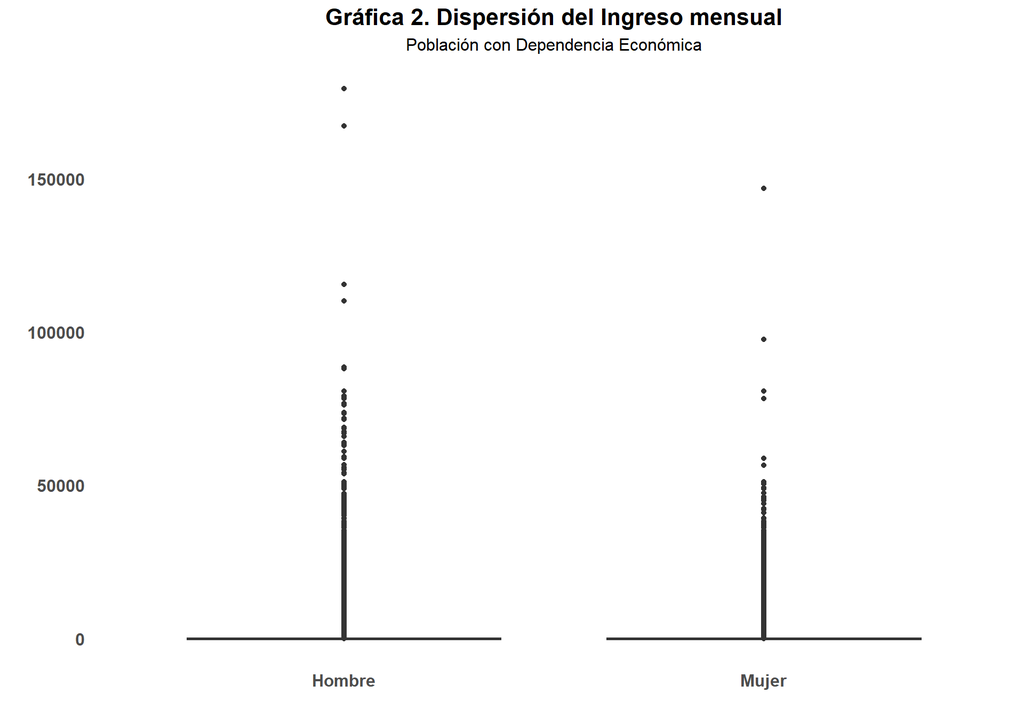

Dado la alta dispersión del Ingreso mensual, es necesario realizar un análisis por separado, primero se analizar la población que es dependiente económica por no ser perceptor de ingresos (ingreso_mensual == 0), el segundo análisis corresponde a la población que es dependiente económica por ser perceptor de ingresos ajenos al trabajo (ingreso > 0)

#### Dependencia económica por no percibir ingresos

Análisis de la población que es dependiente económica por no ser perceptor de ingresos, es decir, su ingreso mensual es igual a cero.

Para fines prácticos, definimos esta dependencia como una nueva variable: “dep_eco_sin_ing”

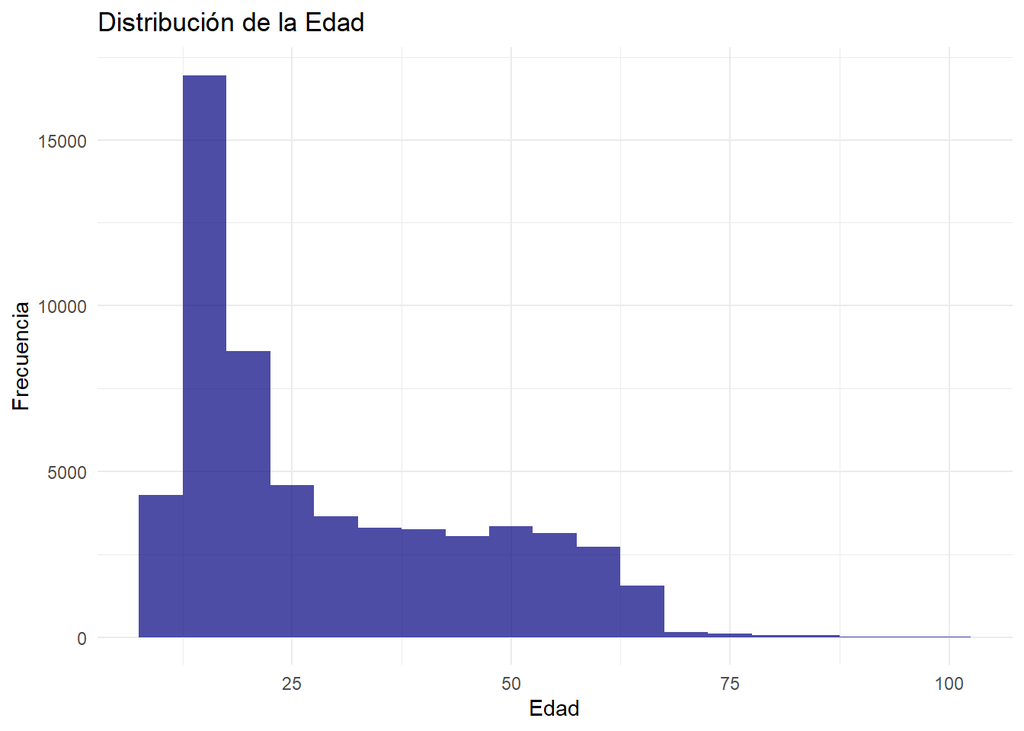

| sexo | n | prop |
| --- | --- | --- |
| Mujer | 41699 | 0.7088773 |
| Hombre | 17125 | 0.2911227 |

| region | n | prop |
| --- | --- | --- |
| Centro | 20607 | 0.35031620 |
| Norte | 19752 | 0.33578131 |
| Sur | 12859 | 0.21860125 |
| Occidente | 5606 | 0.09530124 |

| escolaridad | n | prop |
| --- | --- | --- |
| Secundaria | 23793 | 4.044778e-01 |
| Preparatoria | 12944 | 2.200462e-01 |
| Primaria | 12904 | 2.193662e-01 |
| Licenciatura | 6435 | 1.093941e-01 |
| Ninguno | 1655 | 2.813477e-02 |
| Tecnicatura | 870 | 1.478988e-02 |
| Maestria | 107 | 1.818985e-03 |
| Preescolar | 53 | 9.009928e-04 |
| Normal | 33 | 5.609955e-04 |
| Especialidad | 20 | 3.399973e-04 |

[output cut: 2 more lines]

```
## # A tibble: 2 × 6
##   sexo   conteo media_horas mediana_horas max_horas mediageom_tnr
##   <fct>   <int>       <dbl>         <dbl>     <dbl>         <dbl>
## 1 Hombre  17125        1.82          2.08      4.73          5.16
## 2 Mujer   41699        3.06          3.26      4.73         20.3
```

##### Gráfico de Caja de las Horas de Trabajo no Remunerado

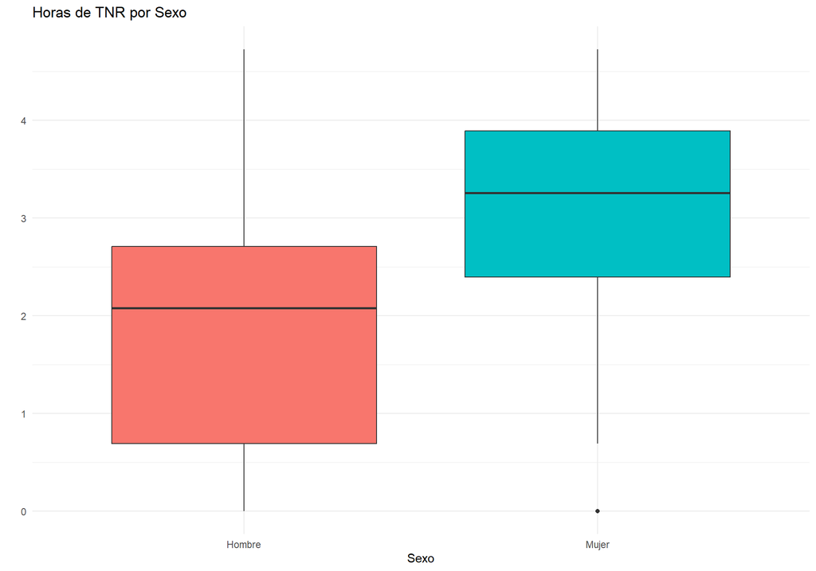

##### Gráfica 1.

Promedio de horas de trabajo no remunerado por sexo de personas dependientes económicas por no percibir ingresos

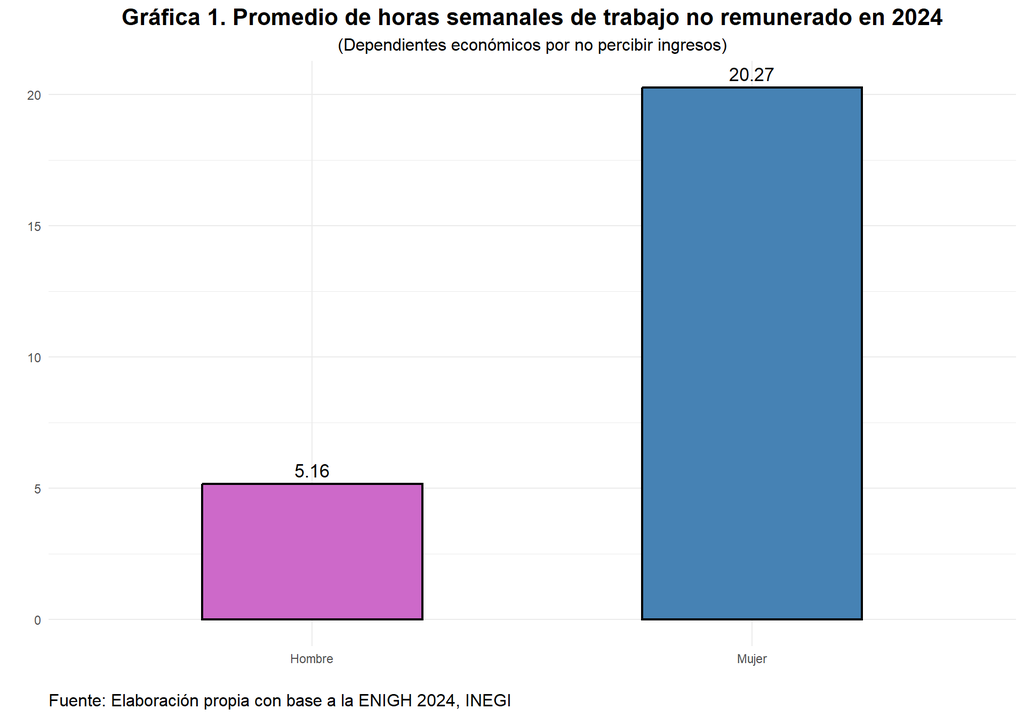

##### Gráfica 2.

Promedio de horas de trabajo no remunerado por sexo y etnia de personas dependientes económicas por no percibir ingresos

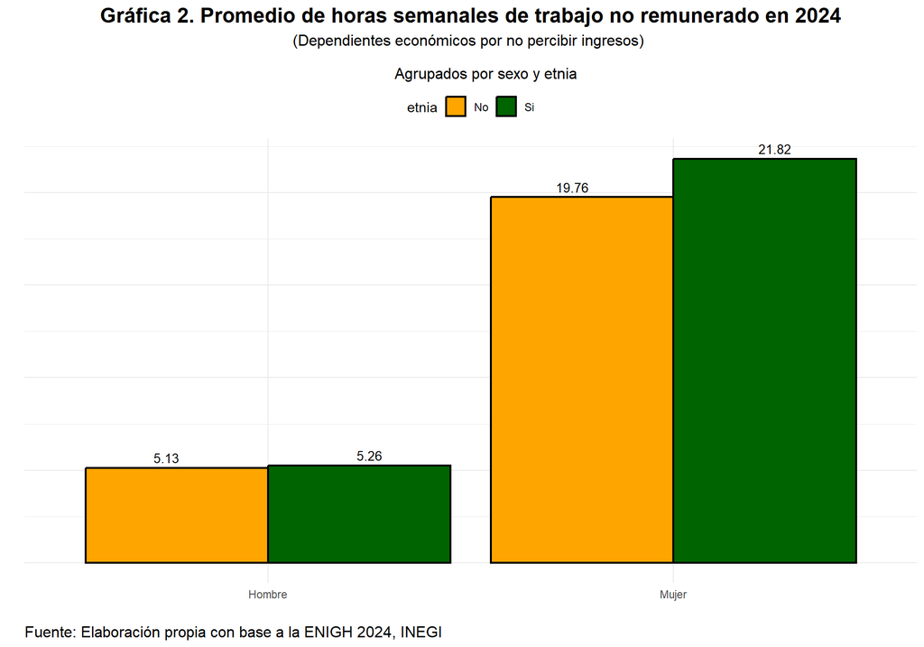

##### Gráfica 3.

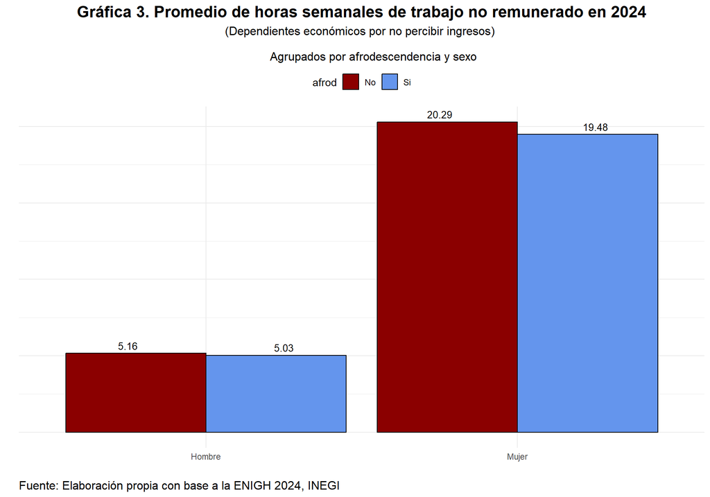

##### Gráfica 4.

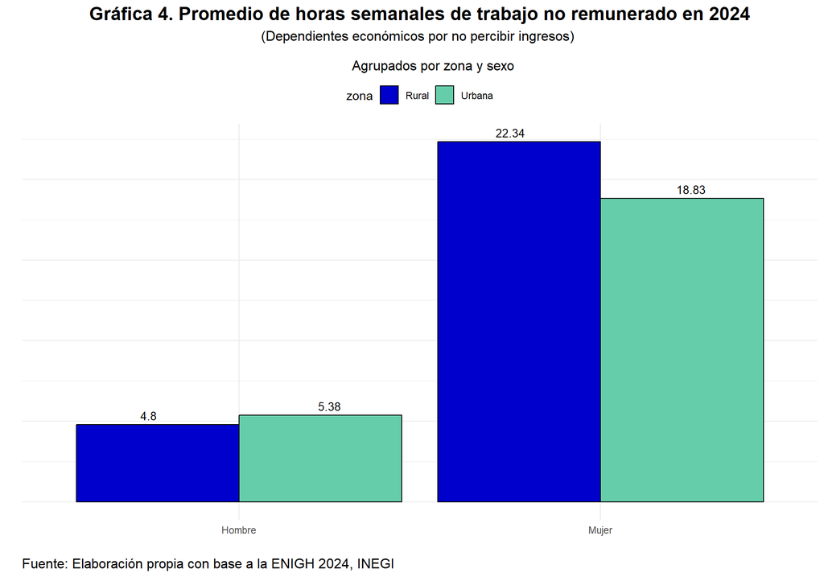

##### Gráfica 5.

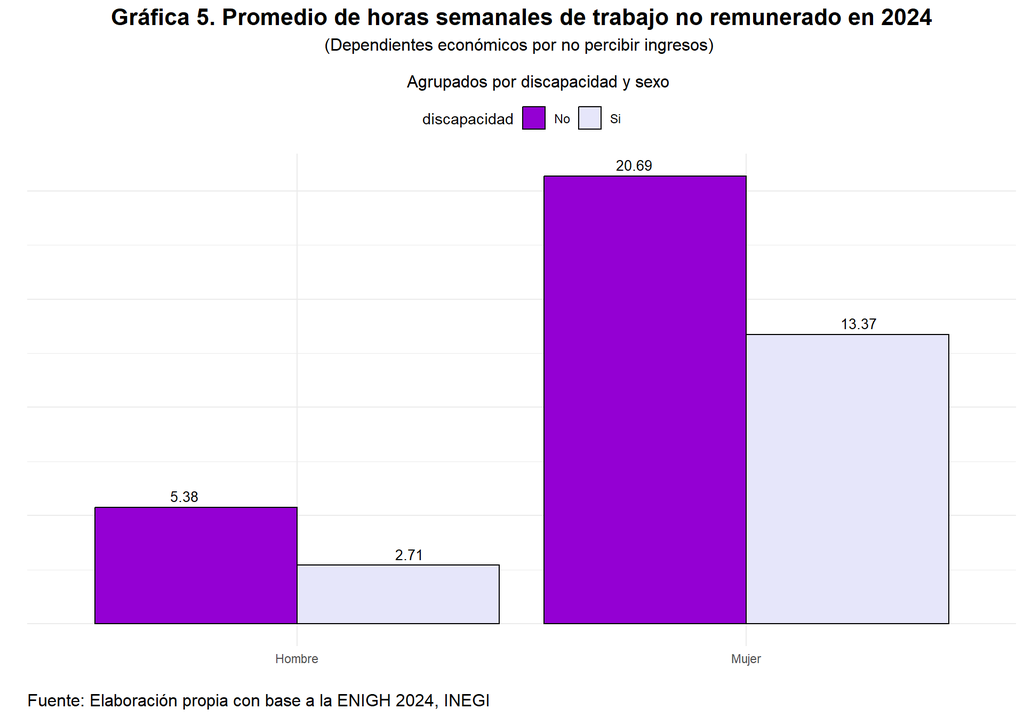

##### Gráfico Combinado

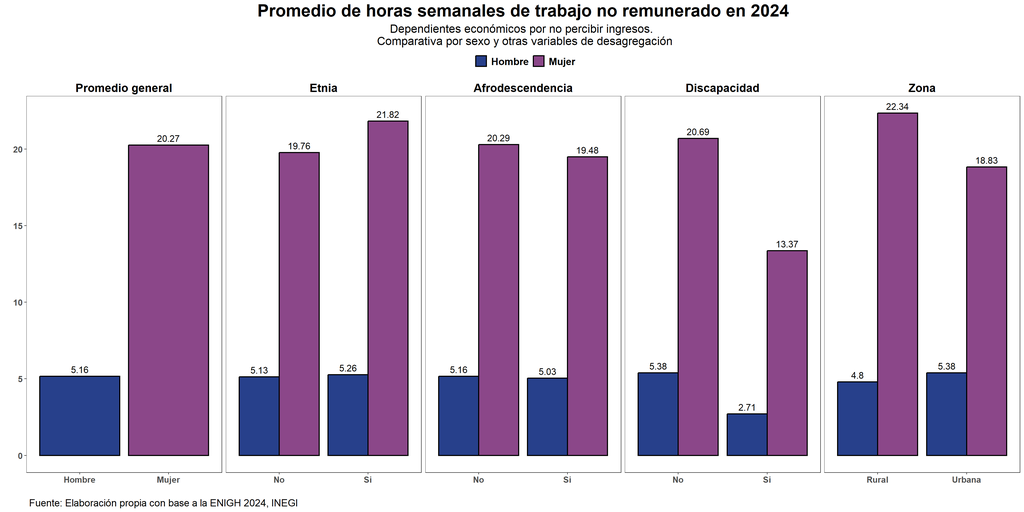

#### Dependencia económica por solo percibir ingresos ajenos al trabajo

Análisis de la población que es dependiente económica por ser perceptores exclusivamente de ingresos ajenos al trabajo

Para fines prácticos, definimos esta dependencia como una nueva variable: “dep_eco_ing”

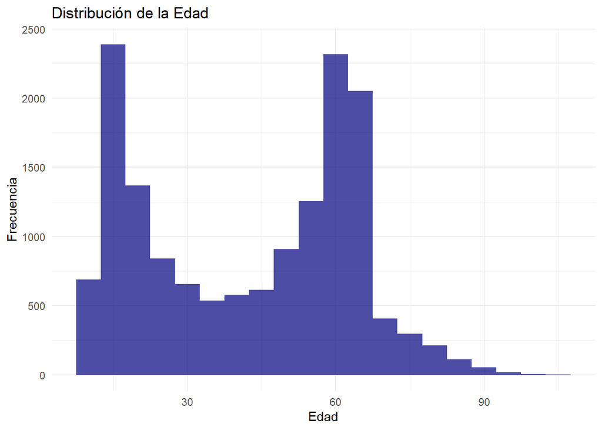

| sexo | n | prop |
| --- | --- | --- |
| Mujer | 10514 | 0.6866062 |
| Hombre | 4799 | 0.3133938 |

| region | n | prop |
| --- | --- | --- |
| Centro | 5515 | 0.36015151 |
| Norte | 5261 | 0.34356429 |
| Sur | 3026 | 0.19760987 |
| Occidente | 1511 | 0.09867433 |

| escolaridad | n | prop |
| --- | --- | --- |
| Secundaria | 5130 | 0.3350094691 |
| Primaria | 4044 | 0.2640893359 |
| Preparatoria | 2537 | 0.1656762228 |
| Licenciatura | 2129 | 0.1390321949 |
| Ninguno | 574 | 0.0374844903 |
| Tecnicatura | 479 | 0.0312806112 |
| Normal | 195 | 0.0127342781 |
| Maestria | 147 | 0.0095996865 |
| Especialidad | 40 | 0.0026121596 |
| Doctorado | 31 | 0.0020244237 |

[output cut: 1 more lines]

##### Gráfico de Cajas

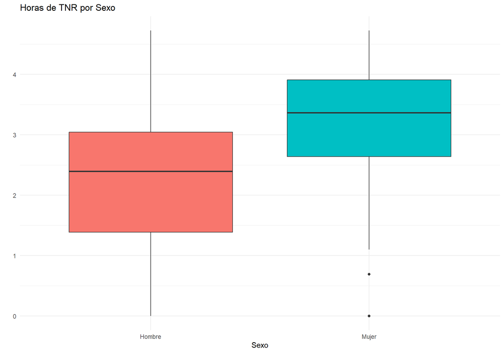

##### Gráfica 1.

Horas de trabajo no remunerado por sexo de personas dependientes económicas por solo percibir ingresos de transferencias.

```
## # A tibble: 2 × 6
##   sexo   conteo media_horas mediana_horas max_horas mediageom_tnr
##   <fct>   <int>       <dbl>         <dbl>     <dbl>         <dbl>
## 1 Hombre   4799        2.12          2.40      4.73          7.33
## 2 Mujer   10514        3.11          3.37      4.73         21.4
```

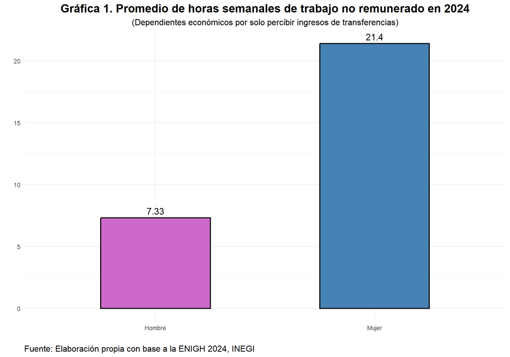

##### Gráfica 2.

Promedio de horas de trabajo no remunerado por sexo y etnia de personas dependientes económicas por solo percibir ingresos ajenos al trabajo

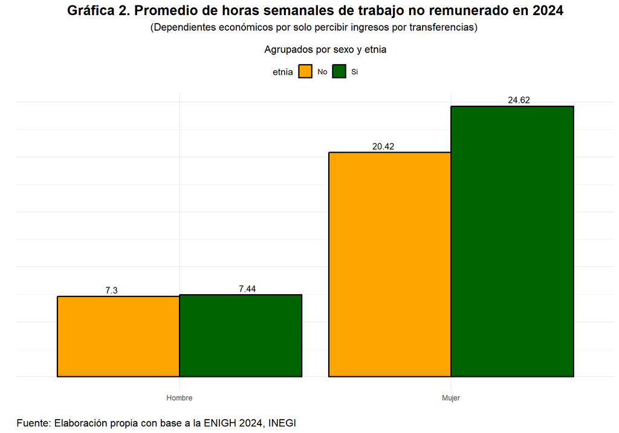

##### Gráfica 3.

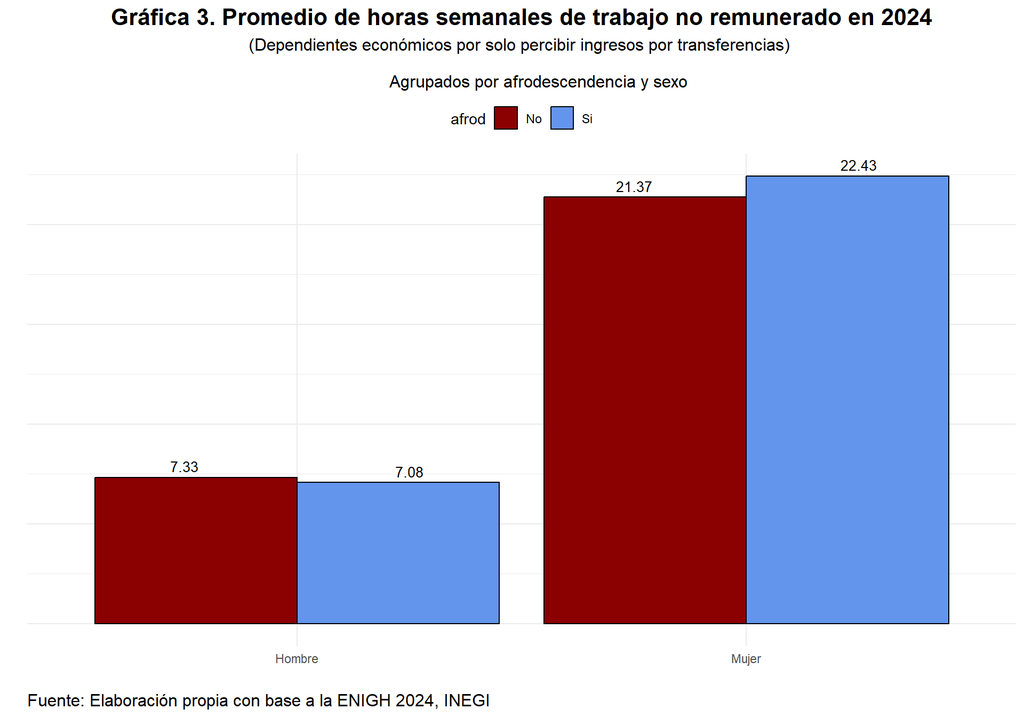

##### Gráfica 4

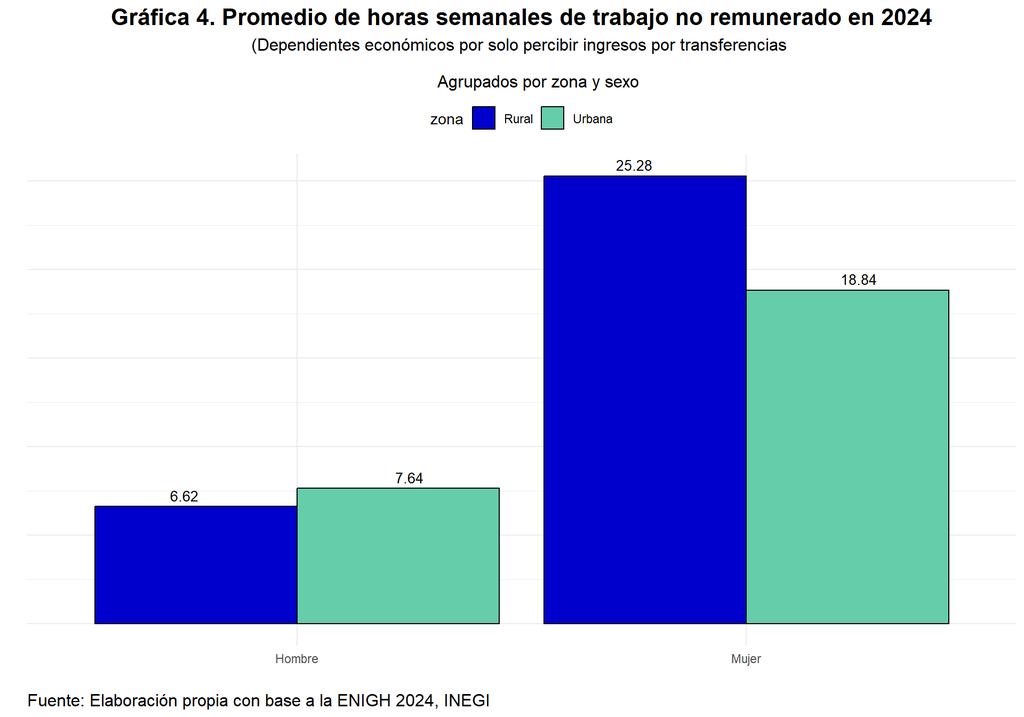

##### Gráfica 5.

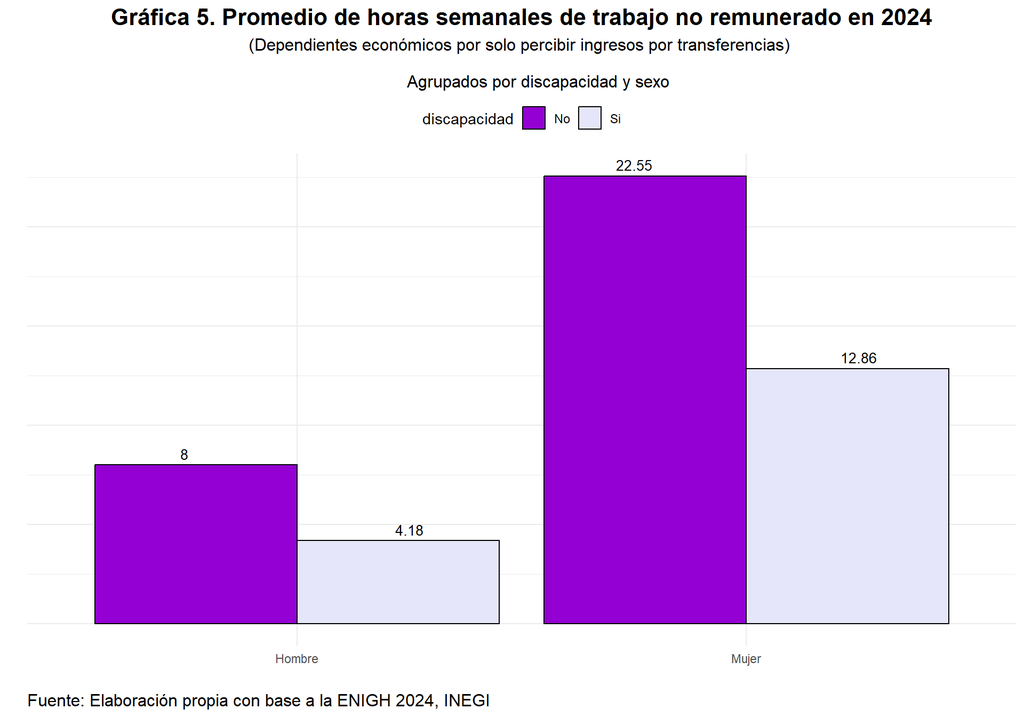

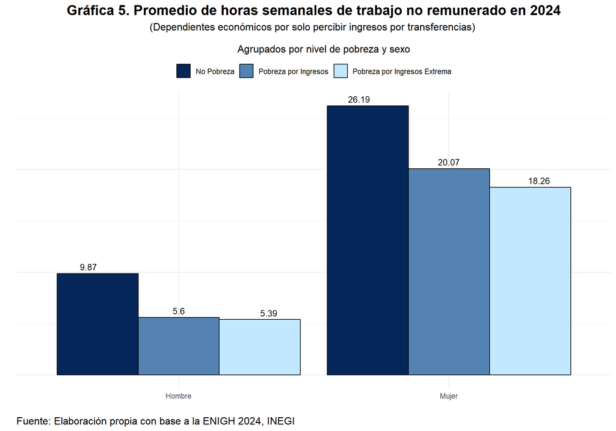

##### Gráfico Combinado (HTNR)

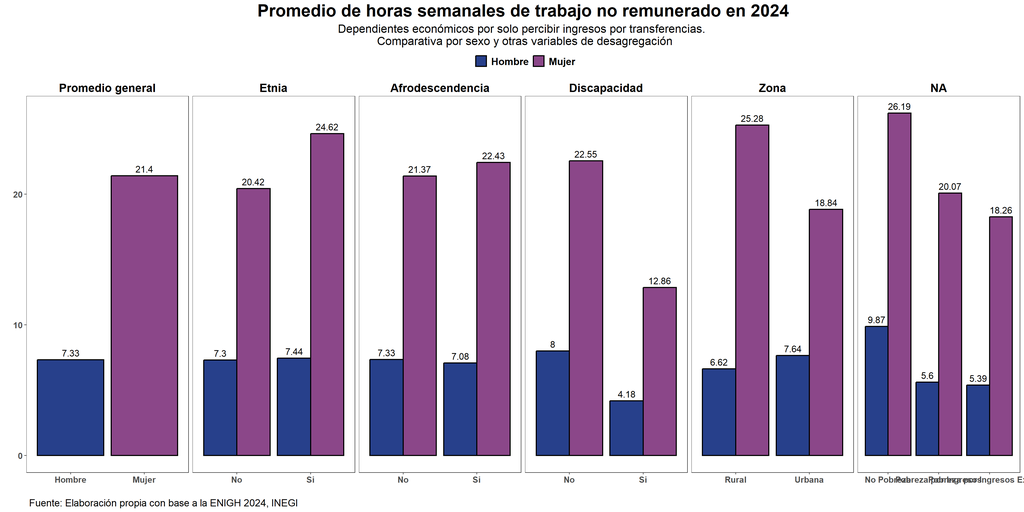

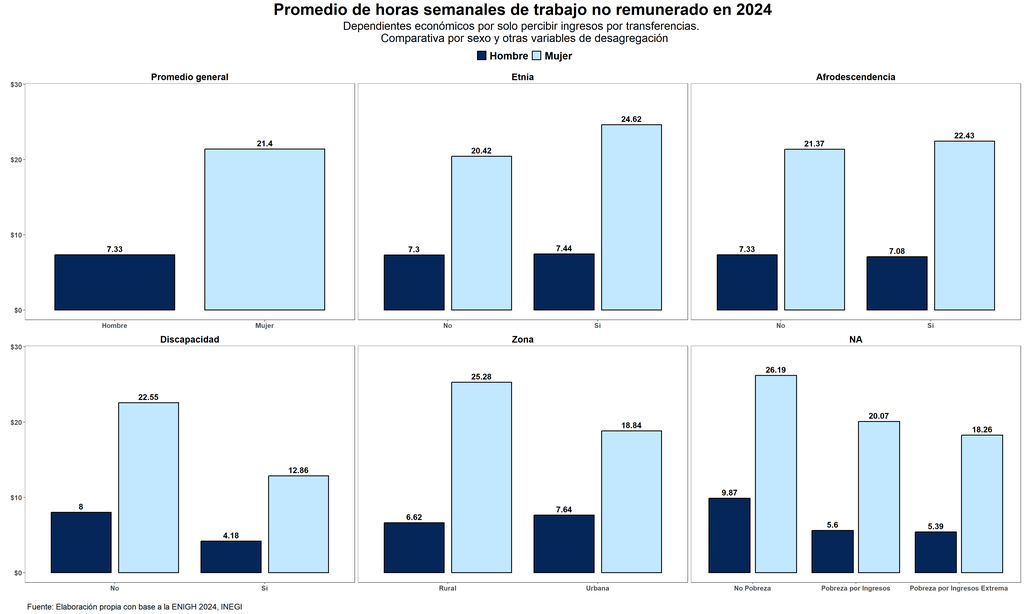

```
## [1] 0.06143875
```

```
## Rows: 15,313
## Columns: 13
## $ FVH             <dbl> 10000370512, 10000370612, 10000560612, 10000720211, 10…
## $ sexo            <fct> Hombre, Mujer, Hombre, Mujer, Mujer, Mujer, Hombre, Mu…
## $ edad            <int> 22, 49, 48, 58, 53, 60, 12, 30, 14, 12, 16, 60, 55, 20…
## $ ingreso_mensual <int> 492, 5902, 32787, 17011, 17604, 25714, 197, 7869, 3934…
## $ nivel_pobreza   <chr> "Pobreza por Ingresos Extrema", "No Pobreza", "No Pobr…
## $ horas_log       <dbl> 3.433987, 3.583519, 2.197225, 1.098612, 4.442651, 2.70…
## $ etnia           <fct> No, No, No, No, No, No, No, No, No, No, No, No, No, No…
## $ afrod           <fct> No, No, No, No, No, No, No, No, No, No, No, No, No, No…
## $ discapacidad    <fct> No, No, No, No, No, No, No, No, No, No, No, No, No, No…
## $ zona            <fct> Urbana, Urbana, Urbana, Urbana, Urbana, Urbana, Urbana…
## $ entidad         <fct> Aguascalientes, Aguascalientes, Aguascalientes, Aguasc…
## $ region          <fct> Centro, Centro, Centro, Centro, Centro, Centro, Centro…
## $ escolaridad     <fct> Preparatoria, Preparatoria, Preparatoria, Licenciatura…
```

##### Gráfica 6.

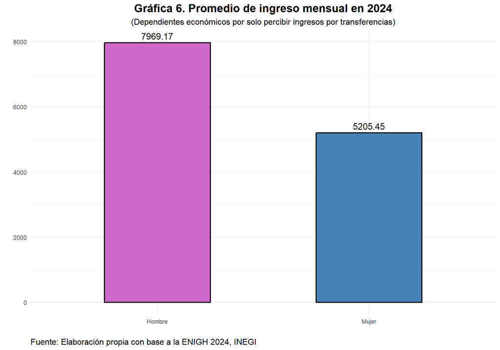

Obtenemos el porcentaje de hombre y mujeres que son dependiente económicos por recibir ingresos solo por transferencias.

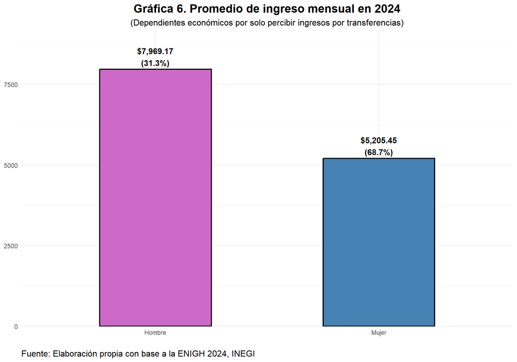

##### Gráfica 7.

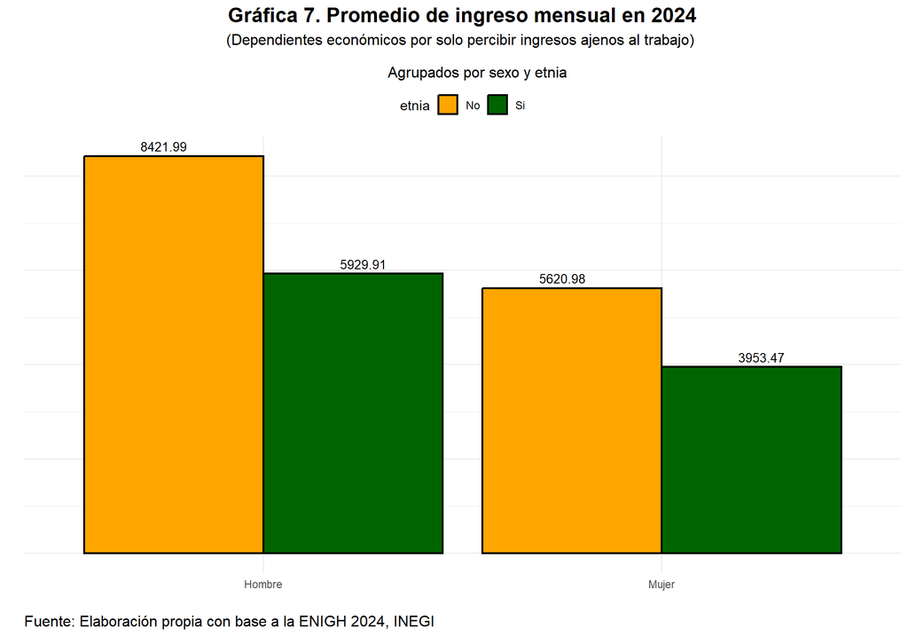

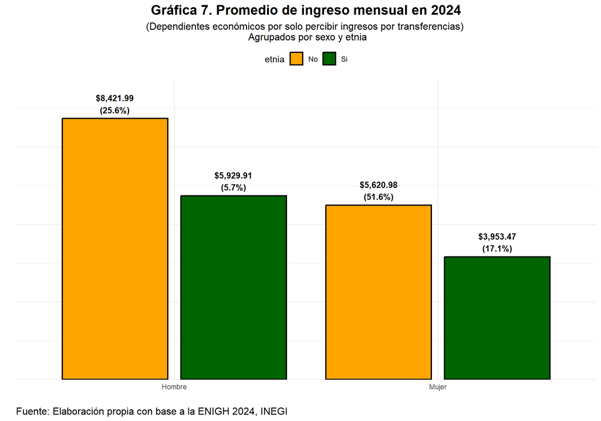

##### Gráfica 8.

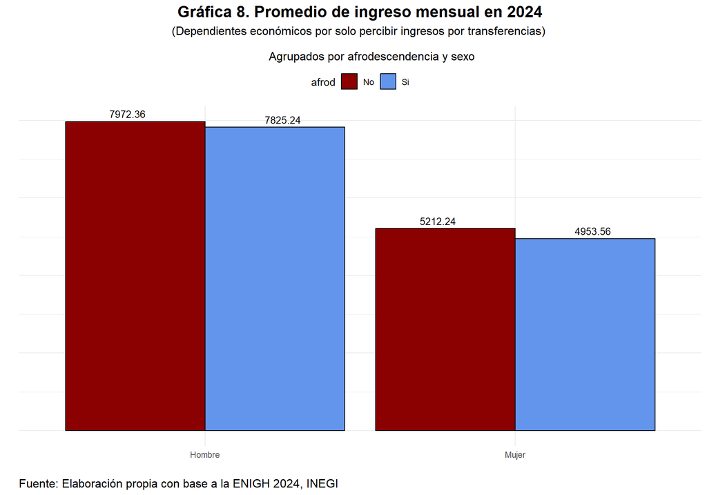

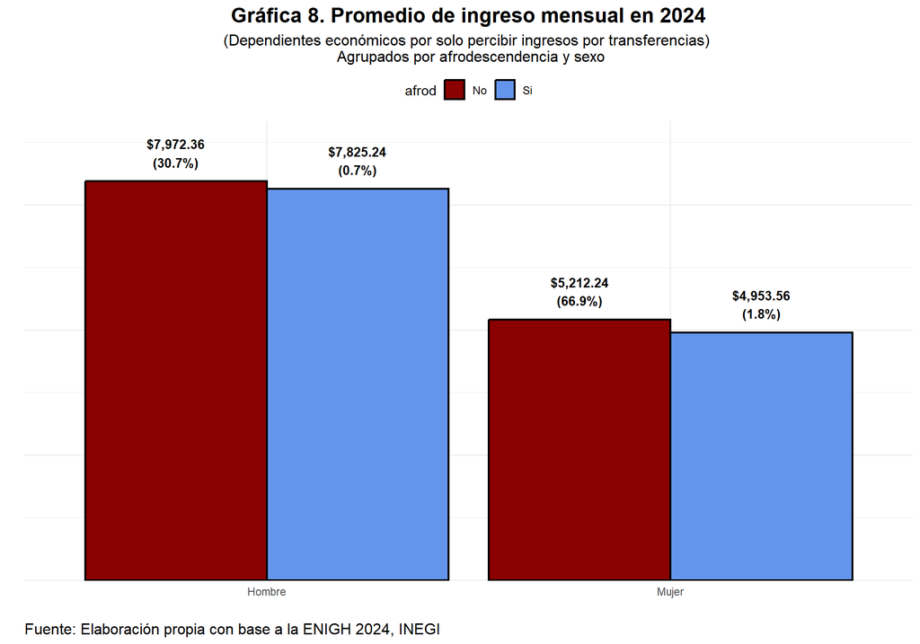